# ATP Tennis Statistics - Version 5

Expanded analysis of match statitistics spanning multiple decades of ATP Professional Tennis seasons.

Jason O’Connell  
2022-03-20

## Latest Overview

Latest iteration (v5) of ATP Tennis Statistics Analysis.

So far exploration has been in the area of relevance of player height on match outcomes on different surfaces and by decades.

For this iteration: I will explore more fully the data available in each data set and see what other topics are interesting.

## Initialize Libraries

```r
library(tidyverse)
library(readr)
library(readxl)
library(dplyr)
library(ggplot2)
```

## Read the data

First read ATP data files, here I am using only the results from 1980, 1990, 2000, 2010 from GITHUB source

The data includes detailed information about each match played on the ATP tour in a given year. Tournament Data: tourney-id (YYYY-###), tourney_name, surface, draw_size, tourney_level, tourney_date Match Data: match_num, score, best_of, minutes, round Player Data (for each winner & loser): _id, _seed, _entry (WC, Q), _name, _hand, _height, _ioc, _age, _rank, _points Match Statistics (for each w & l): _ace, _df, _svpt, _1stIn, _1stWon, _2ndWon, _svGms, _bpSaved, _bpFaced

```r
ATP1980 <- read.csv("https://raw.githubusercontent.com/JeffSackmann/tennis_atp/master/atp_matches_1980.csv")
ATP1990 <- read.csv("https://raw.githubusercontent.com/JeffSackmann/tennis_atp/master/atp_matches_1990.csv")
ATP2000 <- read.csv("https://raw.githubusercontent.com/JeffSackmann/tennis_atp/master/atp_matches_2000.csv")
ATP2010 <- read.csv("https://raw.githubusercontent.com/JeffSackmann/tennis_atp/master/atp_matches_2010.csv")
```

## Including Improved HW4 Plot

First I will improve on my visuals from last HW and look at them with the new data from this homework.

## Insights

In the other files missing court surface isn’t an issue. Let’e redo 1980 eliminating the missing surface rows and inlcude the other years with the same plot:

## 1980

There is some erroneous data where the court surface isn’t included so the filter is set to only include the 4 court surface types.

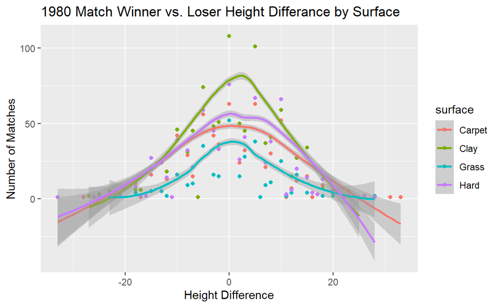

```r
ATP1980 %>%
  drop_na(winner_ht, loser_ht) %>%
  filter(str_detect('Clay|Hard|Carpet|Grass', surface)) %>%
  mutate(ht_diff=winner_ht-loser_ht) %>%
  group_by(surface, ht_diff) %>%
  summarise(surface, ht_diff, count = n()) %>%
  ggplot(aes(x=ht_diff, y=count)) +
    geom_point(aes(color=surface)) +
    geom_smooth(aes(color=surface)) +
    labs(title="1980 Match Winner vs. Loser Height Differance by Surface", x="Height Difference", y="Number of Matches")
```

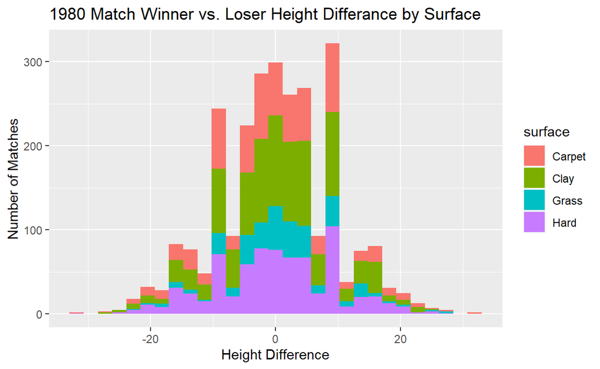

```r
ATP1980 %>%
  drop_na(winner_ht, loser_ht) %>%
  filter(str_detect('Clay|Hard|Carpet|Grass', surface)) %>%
  mutate(ht_diff=winner_ht-loser_ht) %>%
#  group_by(surface, ht_diff) %>%
#  summarise(surface, ht_diff, count = n()) %>%
  ggplot(aes(ht_diff, fill = surface)) +
    geom_histogram() +
    labs(title="1980 Match Winner vs. Loser Height Differance by Surface", x="Height Difference", y="Number of Matches")
```

## 1990

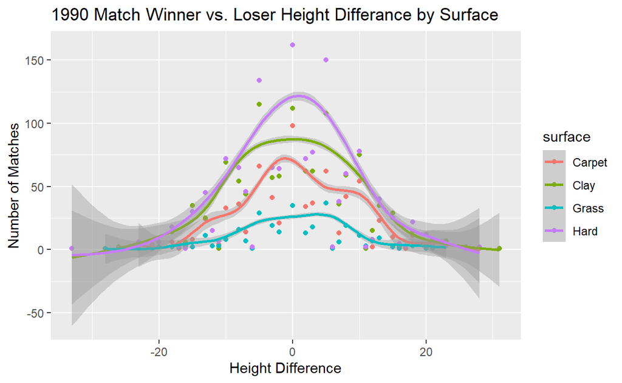

```r
ATP1990 %>%
  drop_na(winner_ht, loser_ht) %>%
  mutate(ht_diff=winner_ht-loser_ht) %>%
  group_by(surface, ht_diff) %>%
  summarise(surface, ht_diff, count = n()) %>%
  ggplot(aes(x=ht_diff, y=count)) +
    geom_point(aes(color=surface)) +
    geom_smooth(aes(color=surface)) +
    labs(title="1990 Match Winner vs. Loser Height Differance by Surface", x="Height Difference", y="Number of Matches")
```

That one looks pretty good.

## 2000

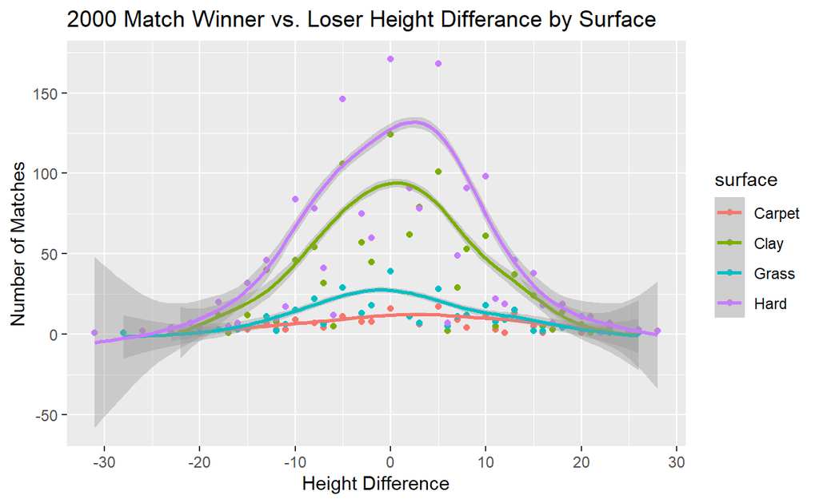

```r
ATP2000 %>%
  drop_na(winner_ht, loser_ht) %>%
  mutate(ht_diff=winner_ht-loser_ht) %>%
  group_by(surface, ht_diff) %>%
  summarise(surface, ht_diff, count = n()) %>%
  ggplot(aes(x=ht_diff, y=count)) +
    geom_point(aes(color=surface)) +
    geom_smooth(aes(color=surface)) +
    labs(title="2000 Match Winner vs. Loser Height Differance by Surface", x="Height Difference", y="Number of Matches")
```

Same for this one.

## 2010

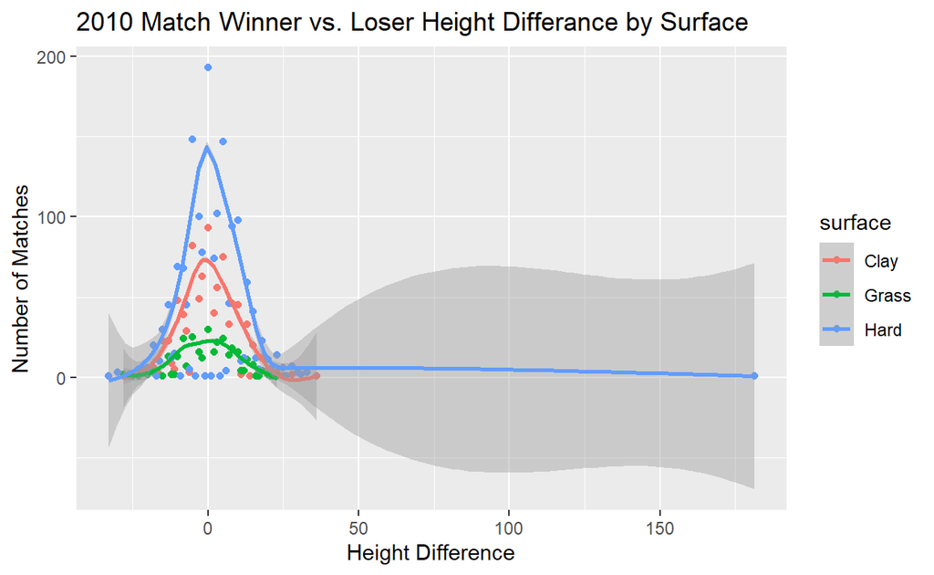

```r
ATP2010 %>%
  drop_na(winner_ht, loser_ht) %>%
  filter(str_detect('Clay|Hard|Grass', surface)) %>%
  mutate(ht_diff=winner_ht-loser_ht) %>%
  group_by(surface, ht_diff) %>%
  summarise(surface, ht_diff, count = n()) %>%
  ggplot(aes(x=ht_diff, y=count)) +
    geom_point(aes(color=surface)) +
    geom_smooth(aes(color=surface)) +
    labs(title="2010 Match Winner vs. Loser Height Differance by Surface", x="Height Difference", y="Number of Matches")
```

Hmmm I’ve got a weird outlier - let’s get rid of that.

## 2010v2

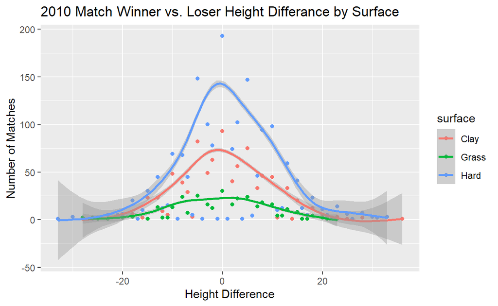

```r
ATP2010 %>%
  drop_na(winner_ht, loser_ht) %>%
  filter(str_detect('Clay|Hard|Grass', surface)) %>%
  mutate(ht_diff=winner_ht-loser_ht) %>%
  filter(ht_diff < 100) %>%
  group_by(surface, ht_diff) %>%
  summarise(surface, ht_diff, count = n()) %>%
  ggplot(aes(x=ht_diff, y=count)) +
    geom_point(aes(color=surface)) +
    geom_smooth(aes(color=surface)) +
    labs(title="2010 Match Winner vs. Loser Height Differance by Surface", x="Height Difference", y="Number of Matches")
```

## Combine the data and compare years

Now I will combine the data sets and see what it looks like over the decades. First let’s look at the violin chart.

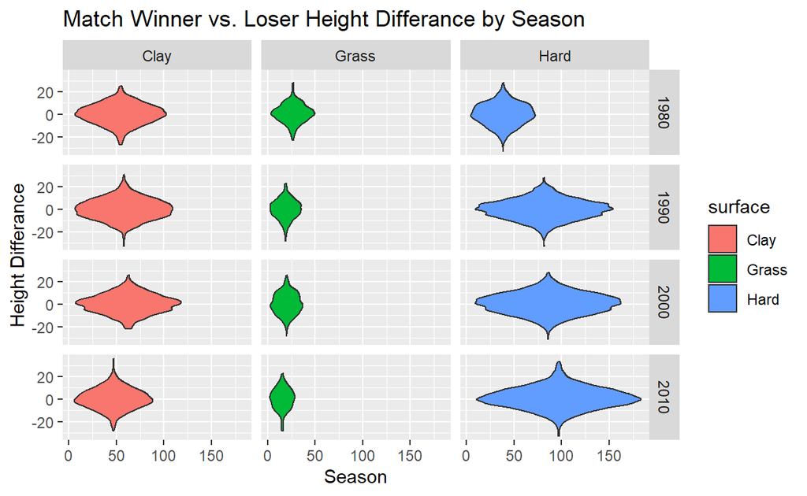

```r
bind_rows(mutate(ATP1980,season = "1980"),mutate(ATP1990, season = "1990"), mutate(ATP2000, season = "2000"), mutate(ATP2010, season = "2010")) %>%
  drop_na(winner_ht, loser_ht) %>%
  filter(str_detect('Clay|Hard|Grass', surface)) %>%
  mutate(ht_diff=winner_ht-loser_ht) %>%
  filter(ht_diff < 100) %>%
  group_by(season, surface, ht_diff) %>%
  summarise(season, surface, ht_diff, count = n()) %>%
  ggplot(aes(x=count, y=ht_diff, fill=surface)) +
    geom_violin() +
    facet_grid(cols=vars(surface), rows=vars(season)) +
    labs(title="Match Winner vs. Loser Height Differance by Season", x="Season", y="Height Differance")
```

## Combined Data Files - Second try

I’d like to plot a faceted set of distributions of height differences and drop the mean as a vertical line.

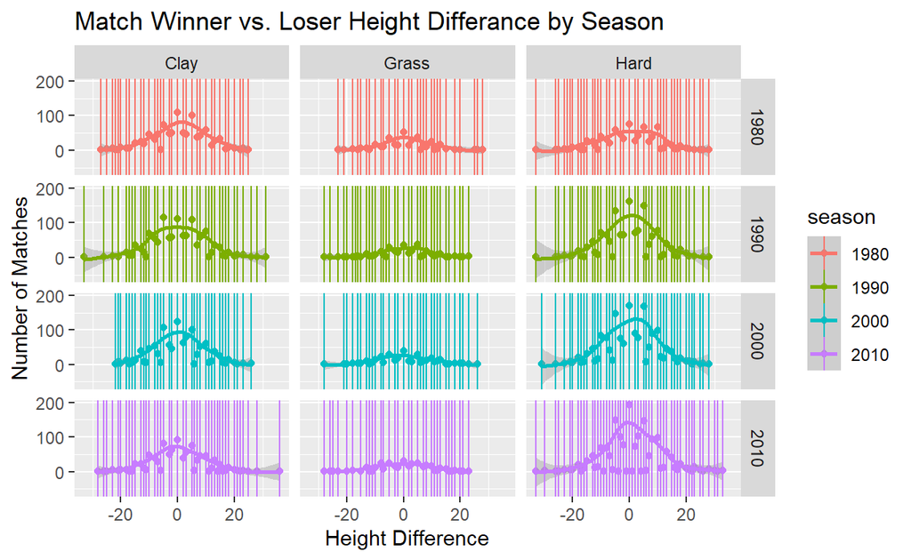

```r
bind_rows(mutate(ATP1980,season = "1980"),mutate(ATP1990, season = "1990"), mutate(ATP2000, season = "2000"), mutate(ATP2010, season = "2010")) %>%
  drop_na(winner_ht, loser_ht) %>%
  filter(str_detect('Clay|Hard|Grass', surface)) %>%
  mutate(ht_diff=winner_ht-loser_ht) %>%
  filter(ht_diff < 100) %>%
  group_by(season, surface, ht_diff) %>%
  summarise(season, surface, ht_diff, ht_mean = mean(ht_diff), count = n()) %>%
  ggplot(aes(x=ht_diff, y=count)) +
    geom_point(aes(color=season)) +
    geom_smooth(aes(color=season)) +
    geom_vline(aes(xintercept=ht_mean, color=season)) +
    facet_grid(cols=vars(surface), rows=vars(season)) +
    labs(title="Match Winner vs. Loser Height Differance by Season", x="Height Difference", y="Number of Matches")
```

Wow that looks terrible. I am not getting the mean correctly. Let’s break it up into components.

## Not quite the ideal results

First let’s combine the data and plot the height difference by surface and season.

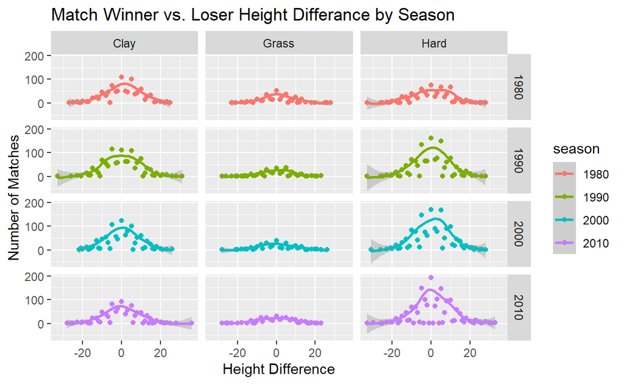

```r
bind_rows(mutate(ATP1980,season = "1980"),mutate(ATP1990, season = "1990"), mutate(ATP2000, season = "2000"), mutate(ATP2010, season = "2010")) %>%
  drop_na(winner_ht, loser_ht) %>%
  filter(str_detect('Clay|Hard|Grass', surface)) %>%
  mutate(ht_diff=winner_ht-loser_ht) %>%
  filter(ht_diff < 100) %>%
  group_by(season, surface, ht_diff) %>%
  summarise(season, surface, ht_diff, count = n()) %>%
  ggplot(aes(x=ht_diff, y=count)) +
    geom_point(aes(color=season)) +
    geom_smooth(aes(color=season)) +
#    geom_vline(aes(xintercept=ht_mean, color=season)) +
    facet_grid(cols=vars(surface), rows=vars(season)) +
    labs(title="Match Winner vs. Loser Height Differance by Season", x="Height Difference", y="Number of Matches")
```

## Work on the Mean vertical Line

Now let’s try to use the vline and drop the mean on.

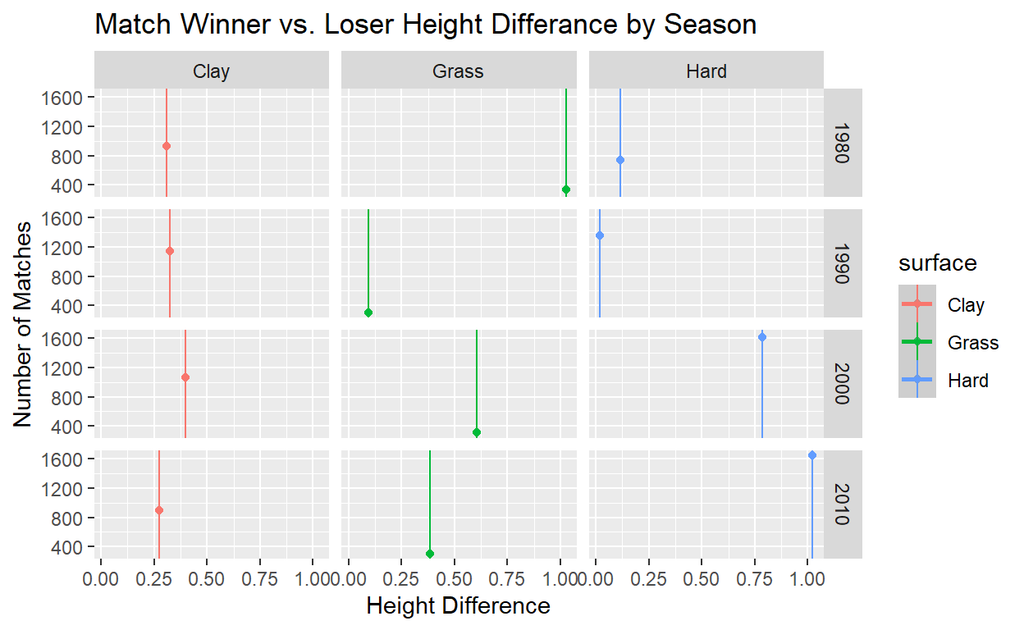

```r
bind_rows(mutate(ATP1980,season = "1980"),mutate(ATP1990, season = "1990"), mutate(ATP2000, season = "2000"), mutate(ATP2010, season = "2010")) %>%
  drop_na(winner_ht, loser_ht) %>%
  filter(str_detect('Clay|Hard|Grass', surface)) %>%
  mutate(ht_diff=winner_ht-loser_ht) %>%
  filter(ht_diff < 100) %>%
  group_by(season, surface) %>%
  summarise(season, surface, ht_mean = mean(ht_diff), count = n()) %>%
  ggplot(aes(x=ht_mean, y=count)) +
    geom_point(aes(color=surface)) +
    geom_smooth(aes(color=surface)) +
    geom_vline(aes(xintercept=ht_mean, color=surface)) +
    facet_grid(cols=vars(surface), rows=vars(season)) +
    labs(title="Match Winner vs. Loser Height Differance by Season", x="Height Difference", y="Number of Matches")
```

## Put it all together

Ok so the first one didn’t calculate the mean for the groupings since counting the number of matches by season, surface, and height difference doesn’t allow me to also calculate the mean heigh differences. I will need to do this separately and merge the results.

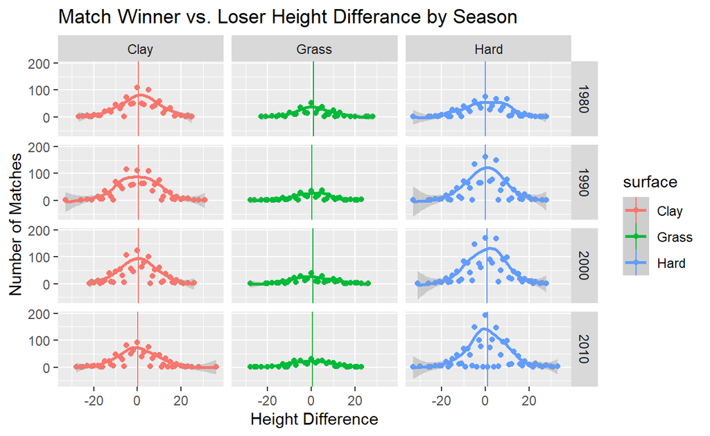

```r
ATPbyDecade<-bind_rows(mutate(ATP1980,season = "1980"),mutate(ATP1990, season = "1990"), mutate(ATP2000, season = "2000"), mutate(ATP2010, season = "2010")) %>%
  drop_na(winner_ht, loser_ht) %>%
  filter(str_detect('Clay|Hard|Grass', surface)) %>%
  mutate(ht_diff=winner_ht-loser_ht) %>%
  filter(ht_diff < 100)

ATP_HtMeanBySrufBySeas<-ATPbyDecade %>%
  group_by(season, surface) %>%
  summarise(season, surface, ht_mean = mean(ht_diff)) %>%
  distinct()

ATP_Summary <- left_join(ATPbyDecade,ATP_HtMeanBySrufBySeas, by = c("season","surface")) %>%
  group_by(season, surface, ht_diff) %>%
  summarise(season, surface, ht_diff, ht_mean = mean(ht_mean), count = n())

ATP_Summary %>%
    ggplot(aes(x=ht_diff, y=count)) +
    geom_point(aes(color=surface)) +
    geom_smooth(aes(color=surface)) +
    geom_vline(aes(xintercept=ht_mean, color=surface)) +
    facet_grid(cols=vars(surface), rows=vars(season)) +
    labs(title="Match Winner vs. Loser Height Differance by Season", x="Height Difference", y="Number of Matches")
```